# Flights Data Explanation

## Preliminary Wrangling

### Airline on-time performance

> This dataset was about all flights in the US, and this data was recorded between (Jan 2017) and (June 2020), and it contains the number of flights on different air-line carriers such as (Delta Air Lines Inc., Endeavor Air Inc., ..., etc. ), and from which airport was the takeoff.

> It shows the total delay time in minutes for all flights, and the delay time went for different reasons.

> The data also has the number of canceled flights and why they canceled

```python
# import all packages and set plots to be embedded inline
import numpy as np
import pandas as pd
import matplotlib.pyplot as plt
import seaborn as sb

%matplotlib inline
```

> Load in your dataset and describe its properties through the questions below. Try and motivate your exploration goals through this section.

### Explore and assess our data

```python
# Read the data
df = pd.read_csv('airline_delay_causes.csv')
df.sample(5)   # we can gather the city name from the airport_name, I think it will help us in further exploration
```

|  | year | month | carrier | carrier_name | airport | airport_name | arr_flights | arr_del15 | carrier_ct | weather_ct | ... | late_aircraft_ct | arr_cancelled | arr_diverted | arr_delay | carrier_delay | weather_delay | nas_delay | security_delay | late_aircraft_delay | Unnamed: 21 |
| --- | --- | --- | --- | --- | --- | --- | --- | --- | --- | --- | --- | --- | --- | --- | --- | --- | --- | --- | --- | --- | --- |
| 49588 | 2018 | 5 | UA | United Air Lines Inc. | DCA | Washington, DC: Ronald Reagan Washington National | 419.0 | 107.0 | 19.60 | 9.76 | ... | 28.24 | 6.0 | 3.0 | 7591.0 | 894.0 | 1425.0 | 2725.0 | 0.0 | 2547.0 | NaN |
| 41044 | 2019 | 9 | AS | Alaska Airlines Inc. | DAL | Dallas, TX: Dallas Love Field | 2.0 | 0.0 | 0.00 | 0.00 | ... | 0.00 | 0.0 | 0.0 | 0.0 | 0.0 | 0.0 | 0.0 | 0.0 | 0.0 | NaN |
| 31945 | 2017 | 12 | AA | American Airlines Inc. | SBA | Santa Barbara, CA: Santa Barbara Municipal | 31.0 | 7.0 | 3.95 | 0.00 | ... | 1.19 | 0.0 | 0.0 | 369.0 | 243.0 | 0.0 | 77.0 | 0.0 | 49.0 | NaN |
| 10580 | 2019 | 3 | F9 | Frontier Airlines Inc. | FAT | Fresno, CA: Fresno Yosemite International | 13.0 | 3.0 | 0.25 | 0.05 | ... | 0.97 | 0.0 | 0.0 | 291.0 | 13.0 | 2.0 | 61.0 | 0.0 | 215.0 | NaN |
| 24405 | 2020 | 3 | YX | Republic Airline | AUS | Austin, TX: Austin - Bergstrom International | 33.0 | 2.0 | 0.00 | 0.00 | ... | 1.53 | 6.0 | 0.0 | 36.0 | 0.0 | 0.0 | 7.0 | 0.0 | 29.0 | NaN |

5 rows × 22 columns

```python
# Use feature Engineering to add a new feature
df['city'] = df.airport_name.str.split(',').str[1].str.split(':').str[0]
```

```python
# Reorder the columns
col = ['year', ' month', 'carrier', 'carrier_name', 'airport', 'airport_name', 'city', 'arr_flights',
       'arr_del15', 'carrier_ct', ' weather_ct', 'nas_ct', 'security_ct', 'late_aircraft_ct',
       'arr_cancelled', 'arr_diverted', ' arr_delay', ' carrier_delay', 'weather_delay',
       'nas_delay', 'security_delay', 'late_aircraft_delay', 'Unnamed: 21']

df = df.reindex(columns=col)
df.sample(2)
```

|  | year | month | carrier | carrier_name | airport | airport_name | city | arr_flights | arr_del15 | carrier_ct | ... | late_aircraft_ct | arr_cancelled | arr_diverted | arr_delay | carrier_delay | weather_delay | nas_delay | security_delay | late_aircraft_delay | Unnamed: 21 |
| --- | --- | --- | --- | --- | --- | --- | --- | --- | --- | --- | --- | --- | --- | --- | --- | --- | --- | --- | --- | --- | --- |
| 17639 | 2019 | 12 | AA | American Airlines Inc. | BHM | Birmingham, AL: Birmingham-Shuttlesworth Inter... | AL | 14.0 | 3.0 | 0.99 | ... | 1.60 | 0.0 | 0.0 | 216.0 | 47.0 | 0.0 | 16.0 | 0.0 | 153.0 | NaN |
| 41479 | 2019 | 9 | F9 | Frontier Airlines Inc. | SBA | Santa Barbara, CA: Santa Barbara Municipal | CA | 13.0 | 2.0 | 1.04 | ... | 0.96 | 0.0 | 0.0 | 337.0 | 112.0 | 0.0 | 0.0 | 0.0 | 225.0 | NaN |

2 rows × 23 columns

```python
df.describe()
```

|  | year | month | arr_flights | arr_del15 | carrier_ct | weather_ct | nas_ct | security_ct | late_aircraft_ct | arr_cancelled | arr_diverted | arr_delay | carrier_delay | weather_delay | nas_delay | security_delay | late_aircraft_delay | Unnamed: 21 |
| --- | --- | --- | --- | --- | --- | --- | --- | --- | --- | --- | --- | --- | --- | --- | --- | --- | --- | --- |
| count | 63552.000000 | 63552.000000 | 63468.000000 | 63290.000000 | 63468.000000 | 63468.000000 | 63468.000000 | 63468.000000 | 63468.000000 | 63468.000000 | 63468.000000 | 63468.000000 | 63468.000000 | 63468.000000 | 63468.000000 | 63468.000000 | 63468.000000 | 0.0 |
| mean | 2018.442818 | 6.045600 | 360.144923 | 63.577801 | 17.815387 | 2.074893 | 20.382412 | 0.118636 | 23.008187 | 9.437134 | 0.839447 | 4182.920779 | 1300.628380 | 220.080986 | 1019.316002 | 5.965274 | 1636.927081 | NaN |
| std | 0.975137 | 3.441145 | 1000.159611 | 172.960731 | 42.922609 | 6.547829 | 65.963093 | 0.534661 | 67.577572 | 61.013949 | 3.558341 | 12407.185932 | 3661.426162 | 803.348102 | 3957.288164 | 37.029969 | 4935.349214 | NaN |
| min | 2017.000000 | 1.000000 | 1.000000 | 0.000000 | 0.000000 | 0.000000 | 0.000000 | 0.000000 | 0.000000 | 0.000000 | 0.000000 | 0.000000 | 0.000000 | 0.000000 | 0.000000 | 0.000000 | 0.000000 | NaN |
| 25% | 2018.000000 | 3.000000 | 47.000000 | 6.000000 | 1.990000 | 0.000000 | 1.070000 | 0.000000 | 1.300000 | 0.000000 | 0.000000 | 313.000000 | 95.000000 | 0.000000 | 38.000000 | 0.000000 | 68.000000 | NaN |
| 50% | 2018.000000 | 6.000000 | 94.000000 | 17.000000 | 5.610000 | 0.330000 | 4.000000 | 0.000000 | 5.180000 | 1.000000 | 0.000000 | 1010.000000 | 345.000000 | 16.000000 | 150.000000 | 0.000000 | 342.000000 | NaN |
| 75% | 2019.000000 | 9.000000 | 243.000000 | 44.000000 | 14.670000 | 1.740000 | 11.730000 | 0.000000 | 15.270000 | 4.000000 | 1.000000 | 2838.000000 | 1024.000000 | 141.000000 | 483.000000 | 0.000000 | 1107.000000 | NaN |
| max | 2020.000000 | 12.000000 | 21931.000000 | 4176.000000 | 1027.450000 | 188.680000 | 1884.420000 | 19.530000 | 1443.450000 | 4951.000000 | 143.000000 | 429194.000000 | 151581.000000 | 28294.000000 | 112018.000000 | 3194.000000 | 147167.000000 | NaN |

```python
df[df[' arr_delay']==429194.0]   # I think it is an outlier, I will check later
```

|  | year | month | carrier | carrier_name | airport | airport_name | city | arr_flights | arr_del15 | carrier_ct | ... | late_aircraft_ct | arr_cancelled | arr_diverted | arr_delay | carrier_delay | weather_delay | nas_delay | security_delay | late_aircraft_delay | Unnamed: 21 |
| --- | --- | --- | --- | --- | --- | --- | --- | --- | --- | --- | --- | --- | --- | --- | --- | --- | --- | --- | --- | --- | --- |
| 3294 | 2017 | 4 | DL | Delta Air Lines Inc. | ATL | Atlanta, GA: Hartsfield-Jackson Atlanta Intern... | GA | 20424.0 | 3370.0 | 1027.45 | ... | 1321.37 | 1197.0 | 101.0 | 429194.0 | 151581.0 | 23334.0 | 107073.0 | 39.0 | 147167.0 | NaN |

1 rows × 23 columns

```python
df.info()
# we have to eliminate (Unnamed: 21 ) column & there is some null values
# we have spaces before some columns as month and weather_ct
```

```
<class 'pandas.core.frame.DataFrame'>
RangeIndex: 63552 entries, 0 to 63551
Data columns (total 23 columns):
 #   Column               Non-Null Count  Dtype
---  ------               --------------  -----
 0   year                 63552 non-null  int64
 1    month               63552 non-null  int64
 2   carrier              63552 non-null  object
 3   carrier_name         63552 non-null  object
 4   airport              63552 non-null  object
 5   airport_name         63552 non-null  object
 6   city                 63552 non-null  object
 7   arr_flights          63468 non-null  float64
 8   arr_del15            63290 non-null  float64
 9   carrier_ct           63468 non-null  float64
 10   weather_ct          63468 non-null  float64
 11  nas_ct               63468 non-null  float64
 12  security_ct          63468 non-null  float64
 13  late_aircraft_ct     63468 non-null  float64
 14  arr_cancelled        63468 non-null  float64
 15  arr_diverted         63468 non-null  float64
 16   arr_delay           63468 non-null  float64
 17   carrier_delay       63468 non-null  float64
 18  weather_delay        63468 non-null  float64
 19  nas_delay            63468 non-null  float64
 20  security_delay       63468 non-null  float64
 21  late_aircraft_delay  63468 non-null  float64
 22  Unnamed: 21          0 non-null      float64
dtypes: float64(16), int64(2), object(5)
memory usage: 11.2+ MB
```

```python
df.carrier.unique()
```

```
array(['AA', 'AS', 'B6', 'DL', 'EV', 'F9', 'HA', 'NK', 'OO', 'UA', 'VX',
       'WN', 'MQ', 'OH', 'YV', 'YX', '9E', 'G4'], dtype=object)
```

```python
df.year.unique()
```

```
array([2017, 2019, 2020, 2018], dtype=int64)
```

```python
df.city.unique()
```

```
array([' NM', ' NY', ' TX', ' GA', ' CT', ' TN', ' ID', ' MA', ' MD',
       ' SC', ' OH', ' NC', ' CO', ' DC', ' IA', ' MI', ' NJ', ' CA',
       ' FL', ' WA', ' HI', ' KS', ' IN', ' WY', ' NV', ' MO', ' PA',
       ' WI', ' MN', ' LA', ' OK', ' NE', ' IL', ' VA', ' OR', ' AZ',
       ' RI', ' ME', ' KY', ' PR', ' UT', ' VI', ' AK', ' VT', ' AL',
       ' MT', ' ND', ' WV', ' SD', ' MS', ' AR', ' NH', ' TT'],
      dtype=object)
```

### clean our data

```python
# Remive the spaces in all columns name
df.columns = df.columns.str.replace(' ', '')
df.info()
```

```
<class 'pandas.core.frame.DataFrame'>
RangeIndex: 63552 entries, 0 to 63551
Data columns (total 23 columns):
 #   Column               Non-Null Count  Dtype
---  ------               --------------  -----
 0   year                 63552 non-null  int64
 1   month                63552 non-null  int64
 2   carrier              63552 non-null  object
 3   carrier_name         63552 non-null  object
 4   airport              63552 non-null  object
 5   airport_name         63552 non-null  object
 6   city                 63552 non-null  object
 7   arr_flights          63468 non-null  float64
 8   arr_del15            63290 non-null  float64
 9   carrier_ct           63468 non-null  float64
 10  weather_ct           63468 non-null  float64
 11  nas_ct               63468 non-null  float64
 12  security_ct          63468 non-null  float64
 13  late_aircraft_ct     63468 non-null  float64
 14  arr_cancelled        63468 non-null  float64
 15  arr_diverted         63468 non-null  float64
 16  arr_delay            63468 non-null  float64
 17  carrier_delay        63468 non-null  float64
 18  weather_delay        63468 non-null  float64
 19  nas_delay            63468 non-null  float64
 20  security_delay       63468 non-null  float64
 21  late_aircraft_delay  63468 non-null  float64
 22  Unnamed:21           0 non-null      float64
dtypes: float64(16), int64(2), object(5)
memory usage: 11.2+ MB
```

```python
# Drop the Unnamed:21 column as all values of this is Nan values
df.drop('Unnamed:21', axis=1, inplace=True)
```

```python
df.dropna(axis=0, inplace=True)
df.info()
```

```
<class 'pandas.core.frame.DataFrame'>
Int64Index: 63290 entries, 0 to 63551
Data columns (total 22 columns):
 #   Column               Non-Null Count  Dtype
---  ------               --------------  -----
 0   year                 63290 non-null  int64
 1   month                63290 non-null  int64
 2   carrier              63290 non-null  object
 3   carrier_name         63290 non-null  object
 4   airport              63290 non-null  object
 5   airport_name         63290 non-null  object
 6   city                 63290 non-null  object
 7   arr_flights          63290 non-null  float64
 8   arr_del15            63290 non-null  float64
 9   carrier_ct           63290 non-null  float64
 10  weather_ct           63290 non-null  float64
 11  nas_ct               63290 non-null  float64
 12  security_ct          63290 non-null  float64
 13  late_aircraft_ct     63290 non-null  float64
 14  arr_cancelled        63290 non-null  float64
 15  arr_diverted         63290 non-null  float64
 16  arr_delay            63290 non-null  float64
 17  carrier_delay        63290 non-null  float64
 18  weather_delay        63290 non-null  float64
 19  nas_delay            63290 non-null  float64
 20  security_delay       63290 non-null  float64
 21  late_aircraft_delay  63290 non-null  float64
dtypes: float64(15), int64(2), object(5)
memory usage: 11.1+ MB
```

```python
df2017 = df[df['year']==2017]
df2018 = df[df['year']==2018]
df2019 = df[df['year']==2019]
df2020 = df[df['year']==2020]
```

```python
df_delay = df[['arr_delay', 'carrier_delay', 'weather_delay', 'security_delay', 'late_aircraft_delay', 'nas_delay']]
df_cancelled = df[['carrier_ct', 'weather_ct', 'nas_ct', 'security_ct', 'late_aircraft_ct', 'arr_cancelled']]
```

### What is the structure of your dataset?

> This data is about flights between 2017-2020, It has some columns to represent the flight date in a month, others to represent the city and airport name and the carrier company, then the rest columns represnt the number of flights, and the delayed or cancelled flights

> I divieded the original dataframe into four dataframes by year, to compare between them

### What is/are the main feature(s) of interest in your dataset?

> The number of flights, the total delay, arr_diverted, and the city.

### What features in the dataset do you think will help support your investigation into your featurce(s) of interest?

> we need to gather city from airport, (carrier_delay, weather_delay, nas_delay, security_delay, and late_aircraft_delay) will give us better understand to arr_delay, and (carrier_ct, weather_ct, nas_ct, security_ct, late_aircraft_ct) will give us better understand to arr_cancelled.

## Univariate Exploration

> In this section, investigate distributions of individual variables. If you see unusual points or outliers, take a deeper look to clean things up and prepare yourself to look at relationships between variables.

#### 1) Number of carrier flights per month

```python
df.arr_flights.describe()
```

```
count    63290.000000
mean       361.126371
std       1001.393130
min          1.000000
25%         48.000000
50%         94.000000
75%        244.000000
max      21931.000000
Name: arr_flights, dtype: float64
```

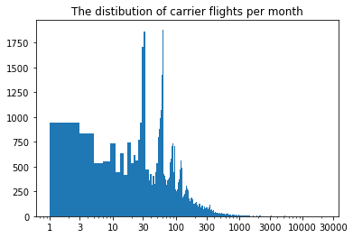

```python
xbins = np.arange(1, 22000, 2)
x_ticks = [1, 3, 10, 30, 100, 300, 1000, 3000, 10000, 30000]

plt.hist(df.arr_flights, bins=xbins);
plt.xscale('log')
plt.xticks(x_ticks,x_ticks)
plt.title('The distibution of carrier flights per month');
```

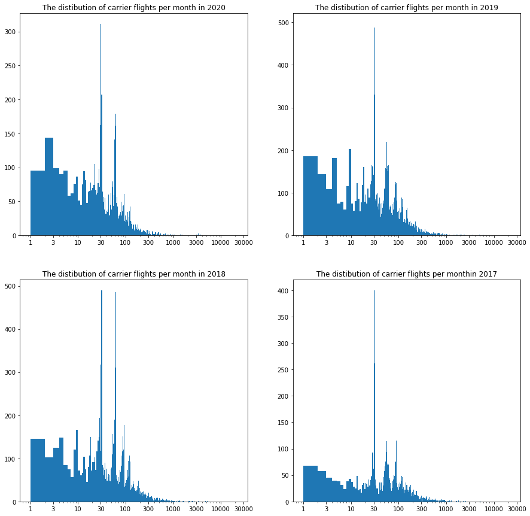

```python
xbins = np.arange(1, 22000, 1)
x_ticks = [1, 3, 10, 30, 100, 300, 1000, 3000, 10000, 30000]

plt.figure(figsize = (15,15))

plt.subplot(2,2,1)
plt.hist(df2020.arr_flights, bins=xbins);
plt.xscale('log')
plt.xticks(x_ticks,x_ticks)
plt.title('The distibution of carrier flights per month in 2020');

plt.subplot(2,2,2)
plt.hist(df2019.arr_flights, bins=xbins);
plt.xscale('log')
plt.xticks(x_ticks,x_ticks)
plt.title('The distibution of carrier flights per month in 2019');

plt.subplot(2,2,3)
plt.hist(df2018.arr_flights, bins=xbins);
plt.xscale('log')
plt.xticks(x_ticks,x_ticks)
plt.title('The distibution of carrier flights per month in 2018');

plt.subplot(2,2,4)
plt.hist(df2017.arr_flights, bins=xbins);
plt.xscale('log')
plt.xticks(x_ticks,x_ticks)
plt.title('The distibution of carrier flights per monthin 2017');
```

- From the previous plot the number of carrier flights per month seems to be right skewed and most of the data lays below the 500

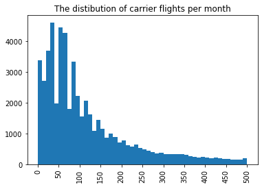

```python
# Zoom in the range bellow 500

xbins = np.arange(0, 510, 10)
x_ticks = np.arange(0,550,50)

plt.hist(df.arr_flights, bins=xbins);
plt.xticks(x_ticks,x_ticks)
plt.xticks(rotation=90)

plt.title('The distibution of carrier flights per month');
```

> Make sure that, after every plot or related series of plots, that you include a Markdown cell with comments about what you observed, and what you plan on investigating next.

#### 2) Delay time per carrier and month

```python
df.arr_delay.describe()
```

```
count     63290.000000
mean       4194.685037
std       12422.635196
min           0.000000
25%         317.000000
50%        1016.000000
75%        2847.750000
max      429194.000000
Name: arr_delay, dtype: float64
```

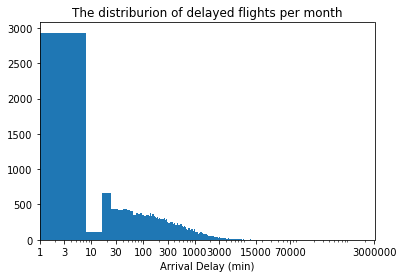

```python
xbins = np.arange(0, 429200, 8)
x_ticks = [1, 3, 10, 30, 100, 300, 1000, 3000, 15000, 70000, 3000000]

plt.hist(df.arr_delay, bins=xbins);
plt.xscale('log')
plt.xticks(x_ticks,x_ticks)
plt.title('The distriburion of delayed flights per month')
plt.xlabel("Arrival Delay (min)");
```

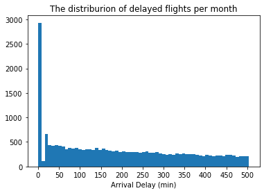

```python
# Zoom in the range bellow 500

xbins = np.arange(0, 508, 8)
x_ticks = np.arange(0, 525, 50)

plt.hist(data=df, x="arr_delay", bins=xbins)

plt.xticks(x_ticks,x_ticks)

plt.title('The distriburion of delayed flights per month')
plt.xlabel("Arrival Delay (min)");
```

```python
df1 = df.groupby(['city']).sum().arr_flights.sort_values(ascending=False)[0:16].reset_index()
idx = df1.city
idx
```

```
0      CA
1      TX
2      FL
3      IL
4      GA
5      NY
6      NC
7      CO
8      AZ
9      MI
10     NV
11     DC
12     PA
13     MN
14     WA
15     OH
Name: city, dtype: object
```

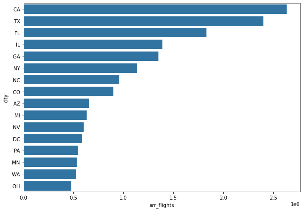

```python
basic_color = sb.color_palette()[0]

plt.figure(figsize = (10, 7))
sb.barplot(data = df1, x = 'arr_flights', y = 'city', color = basic_color);
```

### Discuss the distribution(s) of your variable(s) of interest. Were there any unusual points? Did you need to perform any transformations?

> The ditiburions of flights are right skewed, and all the variables have outliers.

### Of the features you investigated, were there any unusual distributions? Did you perform any operations on the data to tidy, adjust, or change the form of the data? If so, why did you do this?

> I think the distribution of delayed flights per month is as expected because the delayed takeoff should be high in the range of couple minutes and it should be higher than the range of many hours, but also there is something is unusual, as there is a drop in the data between 7-20 min in the distribution of delayed flights per month,

> And also there are some pikes in the distribution of carrier flights per month at about (30,70,100), and the distribution in the low range is pretty high.

> I add a column to represent the city, and I also separate the data by year, I think this will help us to better understand the data

## Bivariate Exploration

> In this section, investigate relationships between pairs of variables in your data. Make sure the variables that you cover here have been introduced in some fashion in the previous section (univariate exploration).

#### 1) Number of flights Vs each month in year

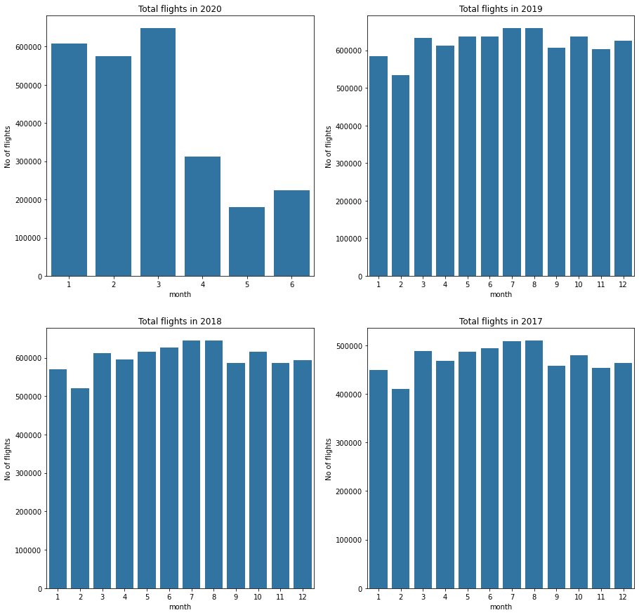

```python
plt.figure(figsize = (15,15))

plt.subplot(2,2,1)  # Plot 2020 data
sb.barplot(x =df2020.groupby(['month']).sum().index,  y=df2020.groupby(['month']).sum().arr_flights, color = basic_color)
plt.title('Total flights in 2020')
plt.ylabel('No of flights')

plt.subplot(2,2,2)  # Plot 2019 data
sb.barplot(x =df2019.groupby(['month']).sum().index,  y=df2019.groupby(['month']).sum().arr_flights, color = basic_color)
plt.title('Total flights in 2019')
plt.ylabel('No of flights')

plt.subplot(2,2,3)  # Plot 2018 data
sb.barplot(x =df2018.groupby(['month']).sum().index,  y=df2018.groupby(['month']).sum().arr_flights, color = basic_color)
plt.title('Total flights in 2018')
plt.ylabel('No of flights')

plt.subplot(2,2,4)  # Plot 2017 data
sb.barplot(x =df2017.groupby(['month']).sum().index,  y=df2017.groupby(['month']).sum().arr_flights, color = basic_color)
plt.title('Total flights in 2017')
plt.ylabel('No of flights');
```

#### 2) Total flight delay Vs Flight delay resons

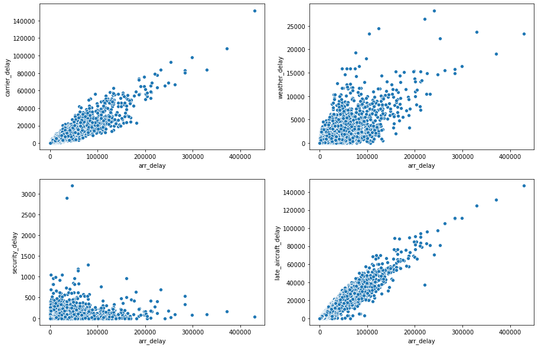

```python
plt.figure(figsize = (15, 10))

plt.subplot(2,2,1)
sb.scatterplot(data = df, x = 'arr_delay', y = 'carrier_delay', color = basic_color)
plt.subplot(2,2,2)
sb.scatterplot(data = df, x = 'arr_delay', y = 'weather_delay', color = basic_color)
plt.subplot(2,2,3)
sb.scatterplot(data = df, x = 'arr_delay', y = 'security_delay', color = basic_color)
plt.subplot(2,2,4)
sb.scatterplot(data = df, x = 'arr_delay', y = 'late_aircraft_delay', color = basic_color);
```

The previous plots show that there are correlations between the total fight delay and the delay resons, but the security delay doesn't make a huge effect, as it has a low correlation with the flight delay

#### 3) Carrier Vs Carrier Delay

```python
idx = df.groupby(['carrier']).median().sort_values('carrier_delay', ascending = False).index
```

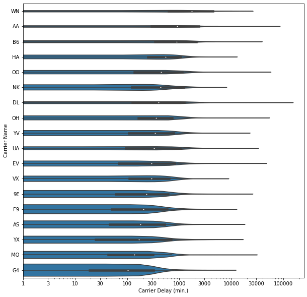

```python
x_ticks = [1, 3, 10, 30, 100, 300, 1000, 3000, 10000, 30000, 100000]

df.carrier_delay.mean()

plt.figure(figsize = (10,10))
sb.violinplot(data=df, x='carrier_delay', y='carrier', order=idx, color=basic_color)
plt.xscale('log')
plt.xticks(x_ticks,x_ticks)
plt.xlabel('Carrier Delay (min.)')
plt.ylabel('Carrier Name');
```

### Talk about some of the relationships you observed in this part of the investigation. How did the feature(s) of interest vary with other features in the dataset?

> We can see from the previous scatter plots that there are highly positive correlations between the total fight delay and other delay reasons, but the security delay doesn't cause a huge effect, as it has a low correlation with the flight delay

> We can see from the violin plot that G4 carrier has the lowest mean, and also it has the largest width, which means that most data fall in the low range, and the data is pretty high, and on the other hand WN has the highest mean and very thin width, and this mean it has low flights, So we can consider that WN has low flight numbers and high delay time due to carrier, and the opposite in G4 carrier, So WN must take care about this delay, this could be a reason to have low flight number.

### Did you observe any interesting relationships between the other features (not the main feature(s) of interest)?

> We can see that the effect of the coronavirus on flight number on the second quarter in 2020, and we can see when the peck occure between months (7,8) and the effect of the virus on this months at 2020.

## Multivariate Exploration

> Create plots of three or more variables to investigate your data even further. Make sure that your investigations are justified, and follow from your work in the previous sections.

#### 1) PairGrid between the delay ressons

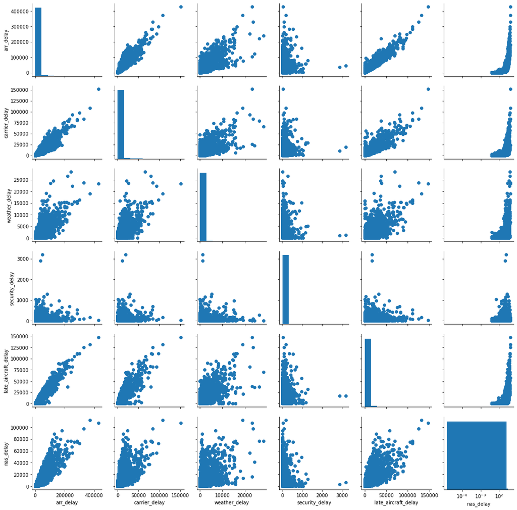

```python
g = sb.PairGrid(data = df_delay)
g.map_diag(plt.hist)
g.map_offdiag(plt.scatter);
plt.xscale('log')
```

#### 2) Heatmap between (year,month and security_cancelation)

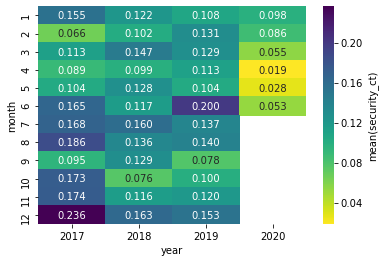

```python
security_ct_mean = df.groupby(['year', 'month']).mean()['security_ct']
security_ct_mean = security_ct_mean.reset_index(name = 'security_ct_avg')
security_ct_means = security_ct_mean.pivot(index = 'month', columns = 'year',
                            values = 'security_ct_avg')

sb.heatmap(security_ct_means, annot = True, fmt = '.3f', cbar_kws = {'label' : 'mean(security_ct)'},  cmap = 'viridis_r');
```

#### 3) Heatmap between (year,month and security_delay)

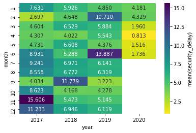

```python
security_delay_mean = df.groupby(['year', 'month']).mean()['security_delay']
security_delay_mean = security_delay_mean.reset_index(name = 'security_delay_avg')
security_delay_means = security_delay_mean.pivot(index = 'month', columns = 'year',
                            values = 'security_delay_avg')

sb.heatmap(security_delay_means, annot = True, fmt = '.3f', cbar_kws = {'label' : 'mean(security_delay)'},  cmap = 'viridis_r');
```

### Talk about some of the relationships you observed in this part of the investigation. Were there features that strengthened each other in terms of looking at your feature(s) of interest?

> We can say that all the delay reasons have some correlation between each other, exept the security that almost has a corrilation=0.

### Were there any interesting or surprising interactions between features?

> Yes, at (Nov-2017, Dec-2017, and Jun-2019) there were many flights that cancelled or delayed because security reasons, I think there were some terrorist operations or something like that in this months.

> At the end of your report, make sure that you export the notebook as an html file from the `File > Download as... > HTML` menu. Make sure you keep track of where the exported file goes, so you can put it in the same folder as this notebook for project submission. Also, make sure you remove all of the quote-formatted guide notes like this one before you finish your report!